# Decoding Consumer Sentiment: Analyzing Trends in Yelp Reviews

## Introduction

Review data is often used by consumers to make many decisions, such as where they should eat and what products they should purchase. It is also used by businesses for purposes such as obtaining feedback and forming competitive comparisons to improve. When using this data, it is important to understand trends in the data so one can more accurately make decisions based on what they see. Interestingly, there is sometimes a disconnect between the actual star rating (1-5 stars with 5 being the best) and the perceived positivity or negativity of a review. This paper explores this idea using Yelp data spanning from 2005 to 2022. Through analyzing the sentiment of around 50,000 reviews, expected insights were found such as reviews that registered as more positive tended to be associated with higher star ratings. Less intuitive insights were also found, like reviews with lower star ratings tended to be more neutral, with lower variability in their tone compared with high starred reviews, which tended to be more polarized, but with higher variability. Finally, a few categories of businesses were selected and explored how their star ratings and sentiment metrics (polarity/subjectivity) compared to each other and varied over time.

## Data Processing

The Yelp data contained many data points, which made running any code take longer than was reasonable. Because of this, I took a random sample of 1,000 businesses from the business dataset and joined it with the review dataset, so all the reviews for each business were in the random sample.

Feature engineering was used to create a new variable that represented the length of each review. The polarity, how negative (-1) or positive (1) the text is, and subjectivity, how factual (0) or opinion-based (1) the text is, of each review was then calculated using the TextBlob library. In addition, a new variable, Abs_polarity, which measured the strength of the polarity by taking the absolute value of the polarity, was created.

Below are the first five rows of the dataset as well as some preliminary statistics and a check for null values. The only variables that had null values were address, attributes, and hours, none of which were used in this analysis.

|  | business_id | name | address | city | state | postal_code | latitude | longitude | stars_business | review_count | ... | funny | cool | text | date | Review Length | Star Sentiment | Polarity | Subjectivity | Abs_polarity | Sentiment |
| --- | --- | --- | --- | --- | --- | --- | --- | --- | --- | --- | --- | --- | --- | --- | --- | --- | --- | --- | --- | --- | --- |
| 0 | L_f14M... | Luca I... | 100 2n... | Saint ... | FL | 33701 | 27.7733 | -82.633806 | 5.0 | 5 | ... | 1 | 1 | This n... | 2016-0... | 629 | Positive | 0.347708 | 0.678889 | 0.347708 | Positive |
| 1 | L_f14M... | Luca I... | 100 2n... | Saint ... | FL | 33701 | 27.7733 | -82.633806 | 5.0 | 5 | ... | 0 | 0 | Phenom... | 2021-0... | 85 | Positive | 0.609375 | 0.716667 | 0.609375 | Positive |
| 2 | L_f14M... | Luca I... | 100 2n... | Saint ... | FL | 33701 | 27.7733 | -82.633806 | 5.0 | 5 | ... | 0 | 0 | Great ... | 2020-0... | 233 | Positive | 0.390000 | 0.578750 | 0.390000 | Positive |
| 3 | L_f14M... | Luca I... | 100 2n... | Saint ... | FL | 33701 | 27.7733 | -82.633806 | 5.0 | 5 | ... | 0 | 0 | My hus... | 2021-0... | 312 | Positive | 0.215260 | 0.558157 | 0.215260 | Positive |
| 4 | L_f14M... | Luca I... | 100 2n... | Saint ... | FL | 33701 | 27.7733 | -82.633806 | 5.0 | 5 | ... | 0 | 0 | Gorgeo... | 2021-0... | 155 | Positive | 0.700000 | 0.950000 | 0.700000 | Positive |

5 rows × 28 columns

|  | latitude | longitude | stars_business | review_count | is_open | stars_review | useful | funny | cool | Review Length | Polarity | Subjectivity | Abs_polarity |
| --- | --- | --- | --- | --- | --- | --- | --- | --- | --- | --- | --- | --- | --- |
| count | 50363.... | 50363.... | 50363.... | 50363.... | 50363.... | 50363.... | 50363.... | 50363.... | 50363.... | 50363.... | 50363.... | 50363.... | 50363.... |
| mean | 35.559602 | -90.478860 | 3.786351 | 277.43657 | 0.817823 | 3.785477 | 1.172508 | 0.325139 | 0.506106 | 570.64... | 0.248511 | 0.564448 | 0.288057 |
| std | 5.491401 | 15.121928 | 0.751343 | 305.53432 | 0.385994 | 1.465665 | 2.812676 | 1.363873 | 2.050777 | 532.09... | 0.237985 | 0.134091 | 0.188194 |
| min | 27.688229 | -119.88... | 1.000000 | 5.00000 | 0.000000 | 1.000000 | 0.000000 | 0.000000 | 0.000000 | 17.000000 | -1.000000 | 0.000000 | 0.000000 |
| 25% | 29.938914 | -90.337143 | 3.500000 | 48.00000 | 1.000000 | 3.000000 | 0.000000 | 0.000000 | 0.000000 | 230.00... | 0.109670 | 0.484946 | 0.143234 |
| 50% | 36.325741 | -86.188308 | 4.000000 | 152.00000 | 1.000000 | 4.000000 | 0.000000 | 0.000000 | 0.000000 | 409.00... | 0.254762 | 0.562143 | 0.266667 |
| 75% | 39.910601 | -82.287938 | 4.500000 | 381.00000 | 1.000000 | 5.000000 | 1.000000 | 0.000000 | 0.000000 | 721.00... | 0.394643 | 0.644444 | 0.400000 |
| max | 53.631919 | -74.700195 | 5.000000 | 1291.0... | 1.000000 | 5.000000 | 132.00... | 77.000000 | 131.00... | 5000.0... | 1.000000 | 1.000000 | 1.000000 |

```
Null Values
```

```
business_id          0
name                 0
address           1027
city                 0
state                0
postal_code          0
latitude             0
longitude            0
stars_business       0
review_count         0
is_open              0
attributes        1033
categories           0
hours             2667
review_id            0
user_id              0
stars_review         0
useful               0
funny                0
cool                 0
text                 0
date                 0
Review Length        0
Star Sentiment       0
Polarity             0
Subjectivity         0
Abs_polarity         0
Sentiment            0
dtype: int64
```

## Exploratory Data Analysis

Figures 1, 2, and 3 show some bar graphs and histograms to get a sense of the distributions of the main variables.

From Figure 1, one can see that the most common star rating of a review was a 5 stars. 4 stars was the next highest, closely followed by 1 star. Not as many reviews had a rating of 2 stars or 3 stars. As one might expect, the distribution of average star rating of a business looks more normal. It’s centered at 4 stars, with more extreme values being less common. Given that 5 stars is the highest possible rating, the distribution is not symmetric, since the right tail is cut off.

Figure 1

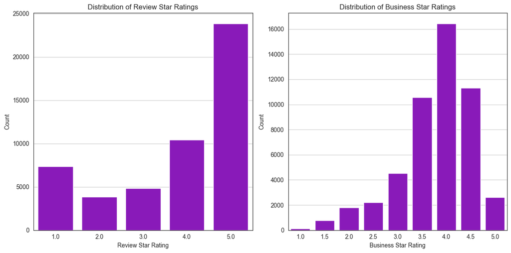

Figure 2

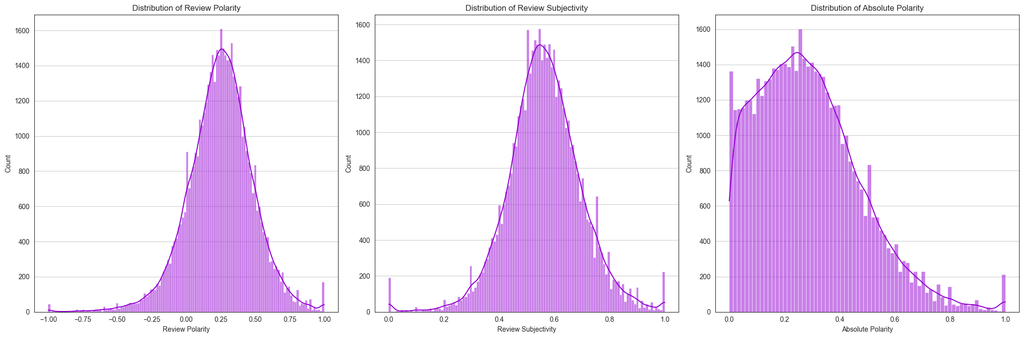

Each business was associated with many different categories, some of which were not very distinct (ex. Restaurants vs. Food). In order to have more digestible insights, I narrowed it down to six categories that I thought were both common and distinct from each other. Figure 3 is a bar graph of the count of each category. Although the “Restaurant” category has the most data points by far at 35,093 points, the other categories also have many data points, with the least frequent, “Hotels & Travel”, having 1,601.

Figure 3

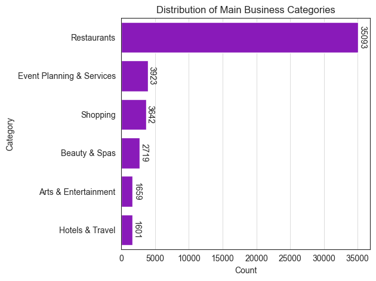

## How the Sentiment Metrics Relate to Star Ratings and Business Categories

Despite the star rating being the intended polarity of a review, sometimes the content of a review doesn’t fully match the rating. Graph 4 explores the relationships between the star rating and the polarity, subjectivity, and polarity strength of the reviews.

The overall trend between polarity and star rating is generally as expected: a higher star rating is associated with a higher polarity. It is interesting to note, however, that even for a star rating of 1, the average polarity is only slightly below 0, indicating only a vaguely negative tone.

The relationship between star rating and subjectivity is less pronounced, but also shows a positive relationship. A higher star rating correlates with more subjectivity. However, that isn’t the only pattern observed. The spread of subjectivities is greater for more extreme star ratings than it is for the middle star ratings. In other words, more extreme star ratings were associated with both higher and lower subjectivities while the middle star ratings tended to be more consistent.

Finally, the relationship between star rating and polarity strength (absolute polarity) is also positive. This is somewhat unexpected because it suggests that lower star ratings tended to be more neutral than higher star ratings, when one might expect the middle star ratings to be more neutral. However, this is consistent with the leftmost graph in Figure 4, which showed the lower star ratings’ polarities centered around 0, and moving upwards (one direction of more extreme) from there. Additionally, the distribution of polarity strength is more bulbous for star ratings of 1 and 2, and more spread for the higher star ratings. This indicates that for lower star ratings, polarity strength is more consistent while for the higher star ratings, it’s more variable.

Figure 4

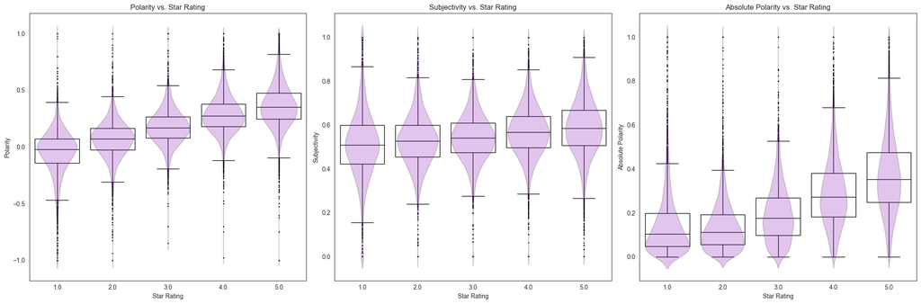

Figure 5 explores if the various sentiment metrics differ by business category. The figure shows them looking fairly similar, but given the large amount of data used, even differences that look minute on the graphs may be statistically significant. Because of this, statistical tests were run to better understand if there were truly differences.

Figure 5

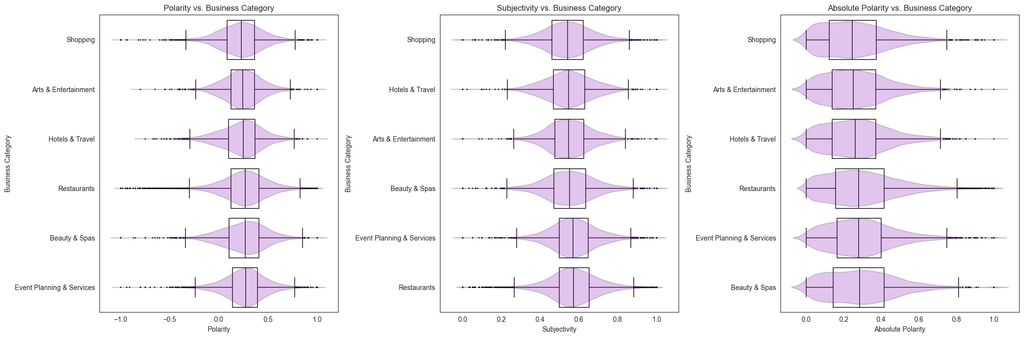

To see if the means of the sentiment metrics differed between business categories, an ANOVA test was run. However, prior to that, the assumptions of the test were checked. Figure 6 shows the results of those checks. While the residuals did not show any significant heteroskedasticity, the QQ plot shows non-normality for the residuals of the tests of all three sentiment metrics. Because of this, I chose to use the Kruskal-Wallis test, and its post-hoc, Dunn’s Test, to compare the medians, since this test does not require the residuals to be normal. To run this test, it is assumed that each review was written independently of other reviews within the same category. This may not be a perfect assumption, given that people are likely to be influenced by other reviews they see, but it is necessary for this test. It is also assumed that the reviews from one category are independent of the reviews in other categories. This is a reasonable assumption, since the six categories chosen are unlikely to have much overlap. Finally, to use this test to compare the medians rather than the mean ranks, it is assumed that the distribution shapes of each sentiment metric are the same across business categories. This seems reasonable, given that the shapes of the box plots and violin plots appear similar within each of the three graphs.

Figure 6

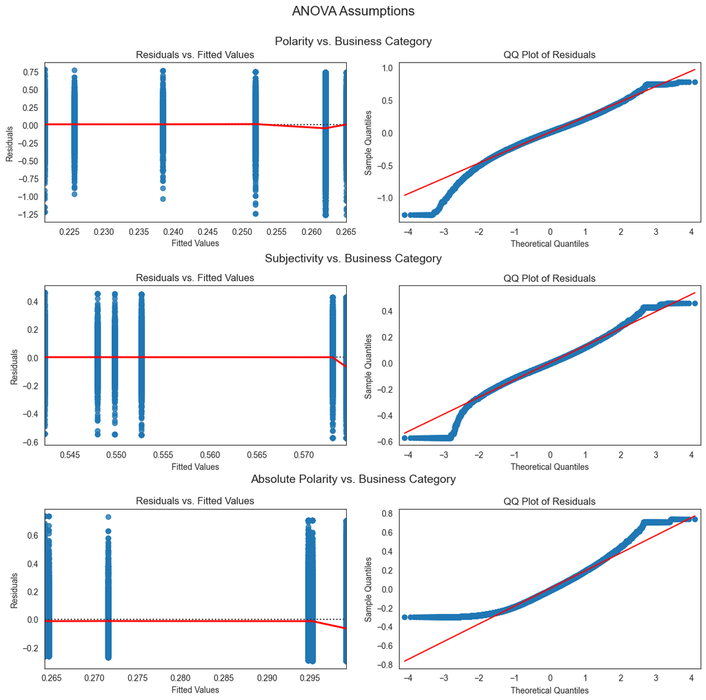

First, the Kruskal-Wallis test was performed to test for a polarity difference between the business categories. The Kruskal-Wallis statistic was 159.01 with a corresponding p-value of approximately 0. This indicates sufficient evidence to reject the null and conclude that there is a difference in the median polarity between at least two of the business categories. To get a better sense of where there were any differences, I ran the post-hoc Dunn’s test with a Bonferroni correction for multiple testing. Table 1 shows the p-values of each pairwise combination. Arts & Entertainment was not statistically different from Hotels & Travel or Shopping. Beauty & Spas was not statistically different from Event Planning or Restaurants. Event Planning was not significantly different from Restaurants. Hotels & Travel was not statistically different from Shopping. All other, unmentioned combinations were statistically significantly different.

```
Kruskal Wallis & Dunn's Test Results for Polarity vs. Business Category
Kruskal-Wallis Statistic: 159.01
P-Value: 1.61e-32
```

Table 1

|  | Arts & Entertainment | Beauty & Spas | Event Planning & Services | Hotels & Travel | Restaurants | Shopping |
| --- | --- | --- | --- | --- | --- | --- |
| Arts & Entertainment | 1.0000 | 0.0249 | 0.0001 | 1.0000 | 0.0 | 0.6696 |
| Beauty & Spas | 0.0249 | 1.0000 | 1.0000 | 0.0027 | 1.0 | 0.0000 |
| Event Planning & Services | 0.0001 | 1.0000 | 1.0000 | 0.0000 | 1.0 | 0.0000 |
| Hotels & Travel | 1.0000 | 0.0027 | 0.0000 | 1.0000 | 0.0 | 1.0000 |
| Restaurants | 0.0000 | 1.0000 | 1.0000 | 0.0000 | 1.0 | 0.0000 |
| Shopping | 0.6696 | 0.0000 | 0.0000 | 1.0000 | 0.0 | 1.0000 |

```
Kruskal Wallis & Dunn's Test Results for Subjectivity vs. Business Category
Kruskal-Wallis Statistic: 362.05
P-Value: 4.46e-76
```

Table 2

|  | Arts & Entertainment | Beauty & Spas | Event Planning & Services | Hotels & Travel | Restaurants | Shopping |
| --- | --- | --- | --- | --- | --- | --- |
| Arts & Entertainment | 1.0 | 1.0000 | 0.0 | 1.0 | 0.0 | 1.0000 |
| Beauty & Spas | 1.0 | 1.0000 | 0.0 | 1.0 | 0.0 | 0.0239 |
| Event Planning & Services | 0.0 | 0.0000 | 1.0 | 0.0 | 1.0 | 0.0000 |
| Hotels & Travel | 1.0 | 1.0000 | 0.0 | 1.0 | 0.0 | 1.0000 |
| Restaurants | 0.0 | 0.0000 | 1.0 | 0.0 | 1.0 | 0.0000 |
| Shopping | 1.0 | 0.0239 | 0.0 | 1.0 | 0.0 | 1.0000 |

Finally, similar results were achieved for polarity strength. This is somewhat expected given that polarity strength is just the absolute value of the polarity. The Kruskal-Wallis statistic was 170.14, corresponding to a p-value of approximately 0. From Table 3, one can see that the same pairwise combinations that were significantly different or not significantly different for polarity were significant or not significant for polarity strength.

```
Kruskal Wallis & Dunn's Test Results for Absolute Polarity vs. Business Category
Kruskal-Wallis Statistic: 170.14
P-Value: 6.80e-35
```

Table 3

|  | Arts & Entertainment | Beauty & Spas | Event Planning & Services | Hotels & Travel | Restaurants | Shopping |
| --- | --- | --- | --- | --- | --- | --- |
| Arts & Entertainment | 1.0 | 0.0000 | 0.000 | 1.0000 | 0.0 | 1.000 |
| Beauty & Spas | 0.0 | 1.0000 | 1.000 | 0.0043 | 1.0 | 0.000 |
| Event Planning & Services | 0.0 | 1.0000 | 1.000 | 0.0010 | 1.0 | 0.000 |
| Hotels & Travel | 1.0 | 0.0043 | 0.001 | 1.0000 | 0.0 | 0.554 |
| Restaurants | 0.0 | 1.0000 | 1.000 | 0.0000 | 1.0 | 0.000 |
| Shopping | 1.0 | 0.0000 | 0.000 | 0.5540 | 0.0 | 1.000 |

## Star Rating Distributions by Business Category

In addition to determining if the sentiment metrics differed across business category, the question of if star rating differed by business category was explored. To get of sense of this, two stacked ba charts were created. For simplicity, the business ratings were rounded down to the nearest whole number (i.e. a rating of 3.5 became 3).

The left chart in Figure 7 indicates that the Event Planning & Services category had the highest proportion of 5-star rated businesses and the Restaurants category had the lowest. Also, both Restaurants and Arts & Entertainment businesses had the highest proportion of 3- and 4-star rated businesses. The distributions of star ratings for each category appear to be different.

The chart on the right in Figure 7 indicates that Beauty & Spa businesses got the highest proportion of 5-star reviews and Arts & Entertainment businesses got the lowest. However, Beauty & Spa businesses also appear to get a higher proportion of 1-star reviews, along with Hotels & Travel and Shopping businesses. Event Planning & Services, Restaurants, and Arts & Entertainment businesses had lower proportions of 1-star reviews. From this graph, it appears that Hotels & Travel and Shopping have similar distributions, along with Restaurants and Arts & Entertainment having similar distributions.

Figure 7

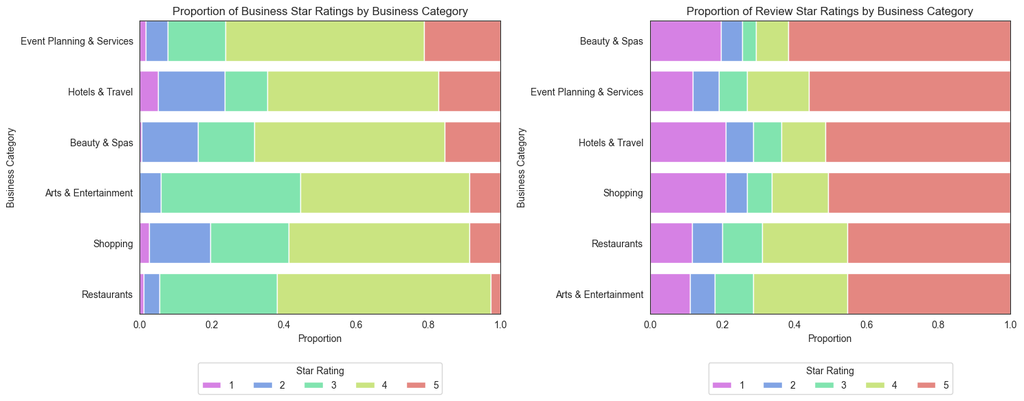

To get a better sense of whether the patterns seen in the graphs are statistically significant, an overall Chi-Square test of homogeneity as well as pairwise chi- square tests were used. In order to run these tests, a small number was added to the contingency table since Arts & Entertainment did not contain any 1-star rated businesses. The overall Chi-Square test resulted in a test statistic of 5772.58, corresponding to a p-value of approximately 0. This indicates sufficient evidence to reject the null hypothesis that the distributions of business star ratings are the same across all categories. To understand how many differences there were and where, pairwise chi-square tests were run (results shown in Table 4), using the Bonferroni correction to adjust for multiple testing. This returned significant p-values for all combinations, indicating sufficient evidence to reject the null and conclude that each category’s distribution of business star ratings differed from the others.

```
Chi-Square Tests for Business Star Ratings by Category
Chi-Square Statistic: 5772.58
P-Value: 0.0
```

Table 4

|  | Adjusted P-Value | Significant |
| --- | --- | --- |
| Restaurants vs. Event Planning & Services | 0.0000... | True |
| Restaurants vs. Shopping | 0.0000... | True |
| Restaurants vs. Beauty & Spas | 0.0000... | True |
| Restaurants vs. Arts & Entertainment | 4.7530... | True |
| Restaurants vs. Hotels & Travel | 0.0000... | True |
| Event Planning & Services vs. Shopping | 1.8395... | True |
| Event Planning & Services vs. Beauty & Spas | 6.5336... | True |
| Event Planning & Services vs. Arts & Entertainment | 1.8765... | True |
| Event Planning & Services vs. Hotels & Travel | 8.4231... | True |
| Shopping vs. Beauty & Spas | 1.5561... | True |
| Shopping vs. Arts & Entertainment | 4.2483... | True |
| Shopping vs. Hotels & Travel | 2.5921... | True |
| Beauty & Spas vs. Arts & Entertainment | 3.5393... | True |
| Beauty & Spas vs. Hotels & Travel | 1.6375... | True |
| Arts & Entertainment vs. Hotels & Travel | 5.7974... | True |

The same tests were run for review star rating., resulting in an overall chi- square test statistic of 1322.4, corresponding to a p-value of approximately 0. This is sufficient evidence to reject the null hypothesis that the distributions of review star ratings are the same across all business categories. The pairwise tests (results shown below) returned mostly statistically significant results, providing sufficient evidence to reject the null that their distributions are the same. There were two exceptions to this. One was Restaurants vs. Arts & Entertainment, giving a p- value of around 0.8, which is much higher than the standard cutoff of 0.05. This does not provide sufficient evidence to reject the null that their distributions are the same. The other exception was somewhat less clear: Shopping vs. Hotels & Travel. This test returned a p-value of around 0.041. While this is below the standard cutoff of 0.05 and thus sufficient evidence to reject the null, it is still somewhat high, warranting cautious interpretation. These exceptions make sense, given that these two combinations looked the closest in the stacked bar chart.

```
Chi-Square Tests for Review Star Ratings by Category
Chi-Square Statistic: 1322.49
P-Value: 4.5204657190659196e-268
```

Table 5

|  | Adjusted P-Value | Significant |
| --- | --- | --- |
| Restaurants vs. Event Planning & Services | 1.0269... | True |
| Restaurants vs. Shopping | 1.6653... | True |
| Restaurants vs. Beauty & Spas | 1.1608... | True |
| Restaurants vs. Arts & Entertainment | 8.0864... | False |
| Restaurants vs. Hotels & Travel | 3.8642... | True |
| Event Planning & Services vs. Shopping | 1.2462... | True |
| Event Planning & Services vs. Beauty & Spas | 1.0142... | True |
| Event Planning & Services vs. Arts & Entertainment | 2.1675... | True |
| Event Planning & Services vs. Hotels & Travel | 1.7089... | True |
| Shopping vs. Beauty & Spas | 8.8060... | True |
| Shopping vs. Arts & Entertainment | 3.2556... | True |
| Shopping vs. Hotels & Travel | 4.0901... | True |
| Beauty & Spas vs. Arts & Entertainment | 1.0970... | True |
| Beauty & Spas vs. Hotels & Travel | 5.1701... | True |
| Arts & Entertainment vs. Hotels & Travel | 4.0893... | True |

## Sentiment and Star Ratings Over Time

The question of if or how review star ratings changed over time for each business category was also explored. From Figure 8, it appears that reviews for Event Planning & Services and Shopping both averaged slightly above 4 stars in 2006. However, as time went on, reviews for Event Planning & Services tended to be higher on average, with the average review rating in 2022 for this category being about 4.7. Shopping instead lowered, with the average review rating in 2022 for this category being about 3.4. Like the Event Planning & Services category, the restaurants category also maintained a steady increase in average review star rating. In 2005, its average review rating was about 3.6, rising to about 4.1 in 2022. At first, the Beauty & Shopping category showed a steady increase, with an average review rating about 3.4 in 2007 rising to about 4.4 in 2016. However, it started dropping afterward, coming to an average review rating of about 3.8 in 2022. The Arts & Entertainment category followed a similar trajectory, starting with about 3.4 in 2007 and rising to about 4.2 in 2017. It also started dropping after that, to about 3.9 in 2022. Finally, Hotels & Travel also had a rise and fall, albeit less pronounced, beginning with an average review rating of about 3.6 in 2009, rising to about 3.9 in 2015 and maintaining that until 2017, then falling to 3.5 in 2022.

Figure 8

[interactive chart not shown]

Finally, the study explored how the sentiment metrics differed over time for each business category. It should be noted that absolute polarity over time mirrors polarity fairly strongly since polarity had more positive values than negative.

All of the sentiment metrics showed a slow, steady rise for Restaurants. Reviews became more positive, more opinion-based, and more strongly expressed. The polarity and absolute polarity of Event Planning & Services reviews remained somewhat steady with a slight upward trend, indicating slightly more positive and strongly expressed reviews. The subjectivity followed a different trend, becoming more opinion-based and then becoming more factual again. The sentiment metrics for Shopping showed a slight increase, then decrease, becoming more positive, opinion-based, and strongly expressed, then trending more negative, factual, and less intense.

The polarity and absolute polarity for Beauty & Spas trended up and then down again, peaking drastically around 2016. The subjectivity followed the same trend, but in a much less pronounced way.

The polarity and absolute polarity for Arts & Entertainment followed the same trends as Beauty & Spas, but with a less pronounced peak. Subjectivity also followed the same trend as Beauty & Spas, but with a more pronounced peak at around 2017.

Finally, polarity and absolute polarity for Hotels & Travel showed a steady rise, becoming slightly more positive and strongly expressed. Subjectivity showed a more substantial rise, becoming more opinion-based.

Figure 9

[interactive chart not shown]

## Conclusion

This study found an expected positive trend between polarity and review star ratings. It was observed that the median polarity for a one-star rating was around 0, indicating that most reviewers tended to keep their reviews from sounding too negative. The study also found a somewhat more surprising positive trend between subjectivity and review star ratings. Since polarity was near neutral even for the lowest ratings, businesses that mainly consider emotional tone could overlook critical signs of dissatisfaction. Low star ratings should be treated as meaningful on their own, even when the accompanying language sounds restrained or neutral.

Finally, the study explored how review star ratings as well as the other sentiment metrics differed over time depending on business category. The shifts over time suggest that relying on static satisfaction benchmarks could mask important changes in user perception. Regularly tracking how overall star ratings and sentiment metrics evolve would allow businesses to identify emerging issues early.

It is important to remember that this analysis used TextBlob, a natural language processing tool that automatically calculated the polarity and subjectivity of each review. While this avoided potential bias compared to doing it manually, it may have resulted in some of those values not being accurate. This should be considered when interpreting the results.

This study also did not explore the reasons behind the findings. It is possible that the differences found are due to demographic differences (i.e. differences in who tends to frequent businesses in each business category). Consequently, it may be fruitful for future research to focus on discovering potential explanations behind these findings.